# Whiprsnapr 2019

Yanick Champoux

January 20, 2020

This version of the report includes the Untappd statistics as of January 18th, 2020. The weeks assigned for each beer might not be an exact match for the real time of release as the dates reported by Untappd are the dates the beers are first checked-in in their system. Still, close enough.

## The beers of 2019

|  | week | url | style | rating | stats.total_count | beer_abv | beer_ibu |
| --- | --- | --- | --- | --- | --- | --- | --- |
| 1 | 01 | Bells Corners Beast | IPA | 3.9 | 29 | 6.66 | 66 |
| 2 | 02 | Xmas Goodies | IPA | 0 | 7 | 7 | 70 |
| 3 | 02 | Firestarter | IPA | 3.4 | 41 | 6 | 61 |
| 4 | 03 | White Devil | IPA | 3.9 | 31 | 6.66 | 66 |
| 5 | 04 | It’s Just A Little Dry Hopped It’s Still Good... It’s Still Good! | Pilsner | 4 | 22 | 4.5 | 20 |
| 6 | 05 | Parley | Traditional Ale | 3.7 | 23 | 0 | 0 |
| 7 | 05 | Parley Tropical Grog | Cream Ale | 0 | 4 | 5.9 | 14 |
| 8 | 05 | Risqué | Stout | 3.8 | 223 | 6.2 | 18 |
| 9 | 06 | Polar Vortex | IPA | 3.7 | 42 | 10 | 80 |
| 10 | 06 | Ice Storm | Bock | 4.1 | 35 | 12 | 30 |

[output cut: 51 more lines]

### Beers without labels

Oh noes! Some of the beers don’t have their proper label set on Untapped.

- [Bells Corners Beast](https://untappd.com/b/whiprsnapr-brewing-co-bells-corners-beast/3030726)
- [Xmas Goodies](https://untappd.com/b/whiprsnapr-brewing-co-xmas-goodies/3035847)
- [Parley Tropical Grog](https://untappd.com/b/whiprsnapr-brewing-co-parley-tropical-grog/3073226)
- [Risqué](https://untappd.com/b/whiprsnapr-brewing-co-risque/3073691)
- [Supernova](https://untappd.com/b/whiprsnapr-brewing-co-supernova/3105106)
- [Oppy](https://untappd.com/b/whiprsnapr-brewing-co-oppy/3115775)
- [Bourbon MICK!](https://untappd.com/b/whiprsnapr-brewing-co-bourbon-mick/3149881)
- [Let’s Go](https://untappd.com/b/whiprsnapr-brewing-co-let-s-go/3172827)
- [Odds & Sods](https://untappd.com/b/whiprsnapr-brewing-co-odds-and-sods/3183322)
- [Craftsman’s Brew](https://untappd.com/b/whiprsnapr-brewing-co-craftsman-s-brew/3196933)
- [Marc of All Trades](https://untappd.com/b/whiprsnapr-brewing-co-marc-of-all-trades/3197811)
- [Sneaky Pete’s Day Buzz All Day Pale Ale](https://untappd.com/b/whiprsnapr-brewing-co-sneaky-pete-s-day-buzz-all-day-pale-ale/3265124)
- [Pops Pale Ale](https://untappd.com/b/whiprsnapr-brewing-co-pops-pale-ale/3279795)
- [My Own Sumr](https://untappd.com/b/whiprsnapr-brewing-co-my-own-sumr/3295451)
- [Just Like Heaven](https://untappd.com/b/whiprsnapr-brewing-co-just-like-heaven/3302739)
- [Merikuh](https://untappd.com/b/whiprsnapr-brewing-co-merikuh/3317187)
- [What Gose Around](https://untappd.com/b/whiprsnapr-brewing-co-what-gose-around/3339709)
- [Winner/Gagnant!](https://untappd.com/b/whiprsnapr-brewing-co-winner-gagnant/3354058)
- [Hoppy IPA Day](https://untappd.com/b/whiprsnapr-brewing-co-hoppy-ipa-day/3364008)
- [Pride](https://untappd.com/b/whiprsnapr-brewing-co-pride/3397693)
- [Back To School](https://untappd.com/b/whiprsnapr-brewing-co-back-to-school/3407089)
- [Black Currant Summer Saison](https://untappd.com/b/whiprsnapr-brewing-co-black-currant-summer-saison/3420922)
- [Raspberry Dreams](https://untappd.com/b/whiprsnapr-brewing-co-raspberry-dreams/3431177)
- [Grand Royal](https://untappd.com/b/whiprsnapr-brewing-co-grand-royal/3438673)
- [Home Harvest 2019](https://untappd.com/b/whiprsnapr-brewing-co-home-harvest-2019/3441344)
- [Toss the Bouquet](https://untappd.com/b/whiprsnapr-brewing-co-toss-the-bouquet/3453883)
- [Fall Spiced Latte](https://untappd.com/b/whiprsnapr-brewing-co-fall-spiced-latte/3464286)
- [Home Harvest (Centennial)](https://untappd.com/b/whiprsnapr-brewing-co-home-harvest-centennial/3474693)
- [Home Harvest (Chinook)](https://untappd.com/b/whiprsnapr-brewing-co-home-harvest-chinook/3476030)
- [Home Harvest (Cascade)](https://untappd.com/b/whiprsnapr-brewing-co-home-harvest-cascade/3486990)
- [Nice Buns](https://untappd.com/b/whiprsnapr-brewing-co-nice-buns/3498359)
- [V](https://untappd.com/b/whiprsnapr-brewing-co-v/3498372)
- [P&Q House Lager](https://untappd.com/b/whiprsnapr-brewing-co-p-and-q-house-lager/3499185)
- [Hoproom 260](https://untappd.com/b/whiprsnapr-brewing-co-hoproom-260/3499782)
- [Candy Dreams](https://untappd.com/b/whiprsnapr-brewing-co-candy-dreams/3510977)
- [William Irish Red](https://untappd.com/b/whiprsnapr-brewing-co-william-irish-red/3521670)
- [The Line Begins To Blur](https://untappd.com/b/whiprsnapr-brewing-co-the-line-begins-to-blur/3537177)
- [Cranberry Pepper Jam](https://untappd.com/b/whiprsnapr-brewing-co-cranberry-pepper-jam/3544429)
- [Guil-tea By Association](https://untappd.com/b/whiprsnapr-brewing-co-guil-tea-by-association/3555320)
- [German Xmas Bread Saison](https://untappd.com/b/whiprsnapr-brewing-co-german-xmas-bread-saison/3564719)
- [Chocolate Hazelnut Brown Ale](https://untappd.com/b/whiprsnapr-brewing-co-chocolate-hazelnut-brown-ale/3564756)
- [Lump of Coal](https://untappd.com/b/whiprsnapr-brewing-co-lump-of-coal/3567301)
- [Mint Chocolate Sweet Stout](https://untappd.com/b/whiprsnapr-brewing-co-mint-chocolate-sweet-stout/3567417)
- [Pride Apricot](https://untappd.com/b/whiprsnapr-brewing-co-pride-apricot/3576418)
- [Nog Hog](https://untappd.com/b/whiprsnapr-brewing-co-nog-hog/3590285)
- [Christmas Bitters Sour](https://untappd.com/b/whiprsnapr-brewing-co-christmas-bitters-sour/3590763)

## Number of releases per week

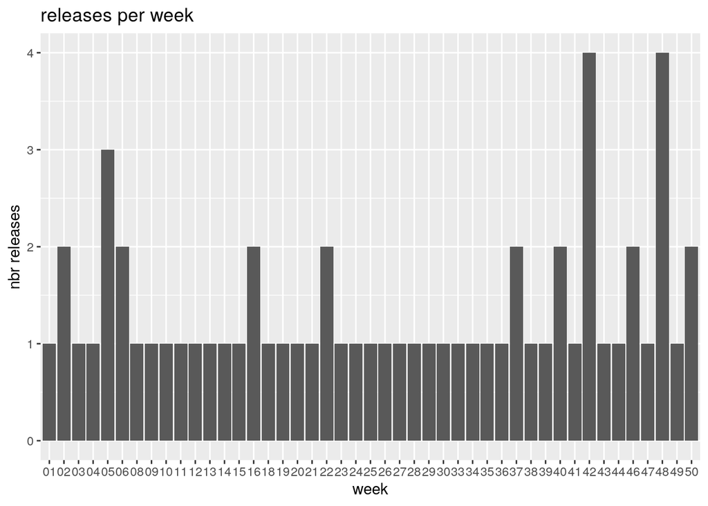

## Beer styles

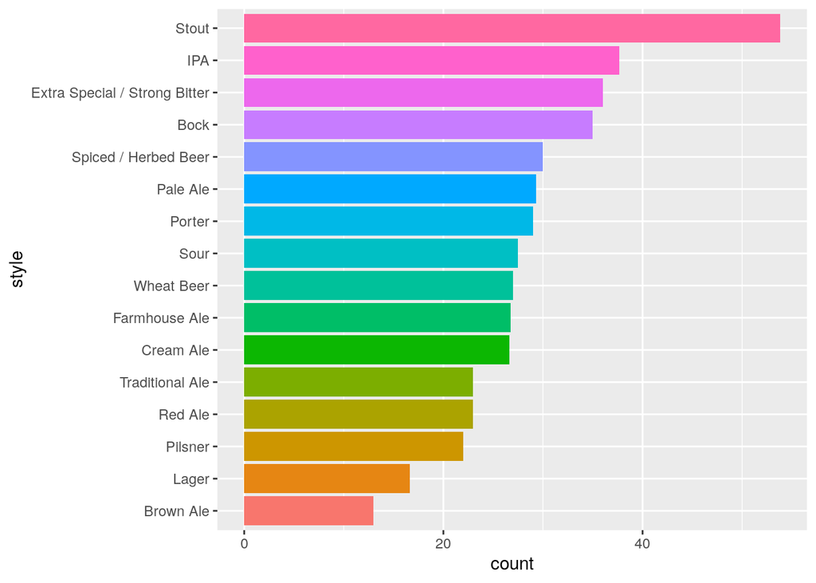

```r
datatable(byStyle %>% select(style,abv,ibu,rating,count)%>% mutate(abv=round(abv,1),ibu=round(ibu,1),rating=round(rating,1),count=round(count,1)),options = list(pageLength = 15))
```

|  | style | abv | ibu | rating | count |
| --- | --- | --- | --- | --- | --- |
| 1 | Bock | 12 | 30 | 4.1 | 35 |
| 2 | Brown Ale | 5.6 | 23 | 4 | 13 |
| 3 | Cream Ale | 5.1 | 17.4 | 3 | 26.6 |
| 4 | Extra Special / Strong Bitter | 5.9 | 59 | 3.9 | 36 |
| 5 | Farmhouse Ale | 6.2 | 25 | 3.5 | 26.8 |
| 6 | IPA | 6.6 | 62.7 | 3.4 | 37.7 |
| 7 | Lager | 4.3 | 20 | 1.8 | 16.6 |
| 8 | Pale Ale | 4.9 | 35.7 | 2.7 | 29.3 |
| 9 | Pilsner | 4.5 | 20 | 4 | 22 |
| 10 | Porter | 5.6 | 20.3 | 3.9 | 29 |

[output cut: 6 more lines]

## ABV vs IBU

Let’s dwelve in the serious numbers. ABV, IBU, how do they correlate?

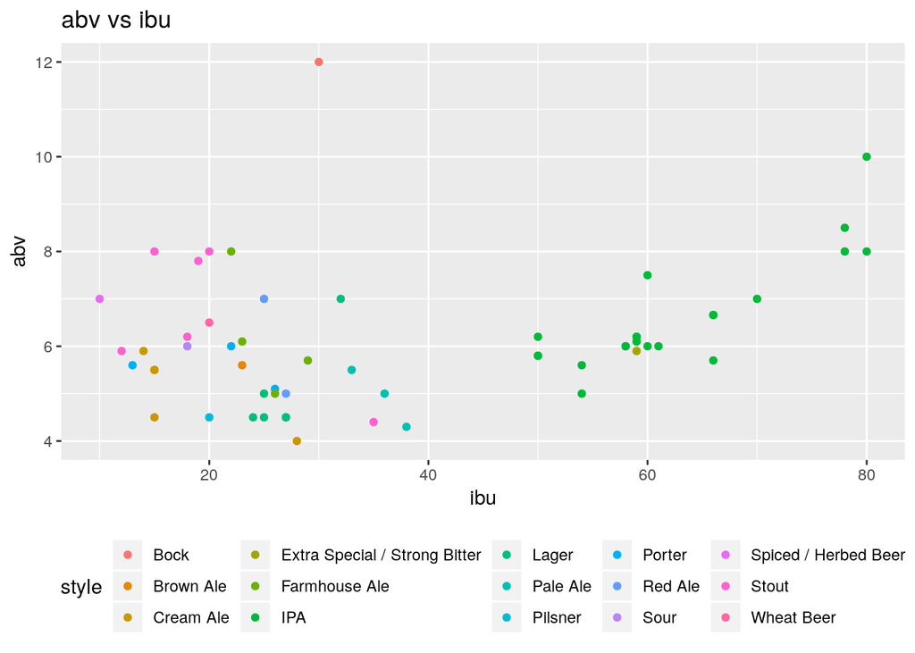

The abv/ibu signature of each style become much more clear when we split the overall graph into by-style parts.

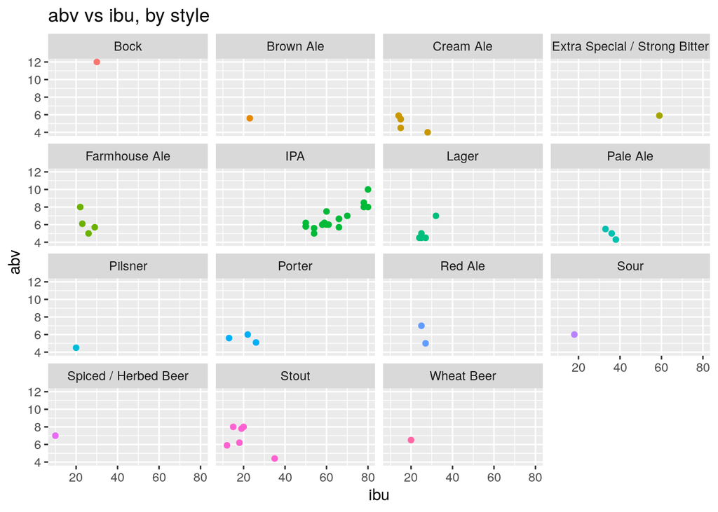

## Getting more love?

Are the beers getting higher rating as the year progress? Nope, we loved them hard all year ’round.

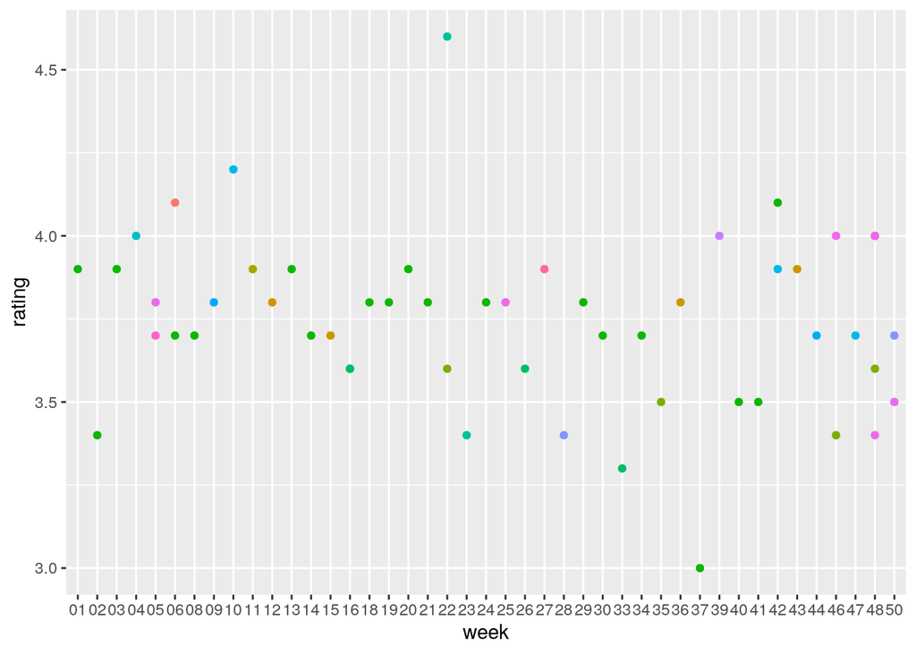

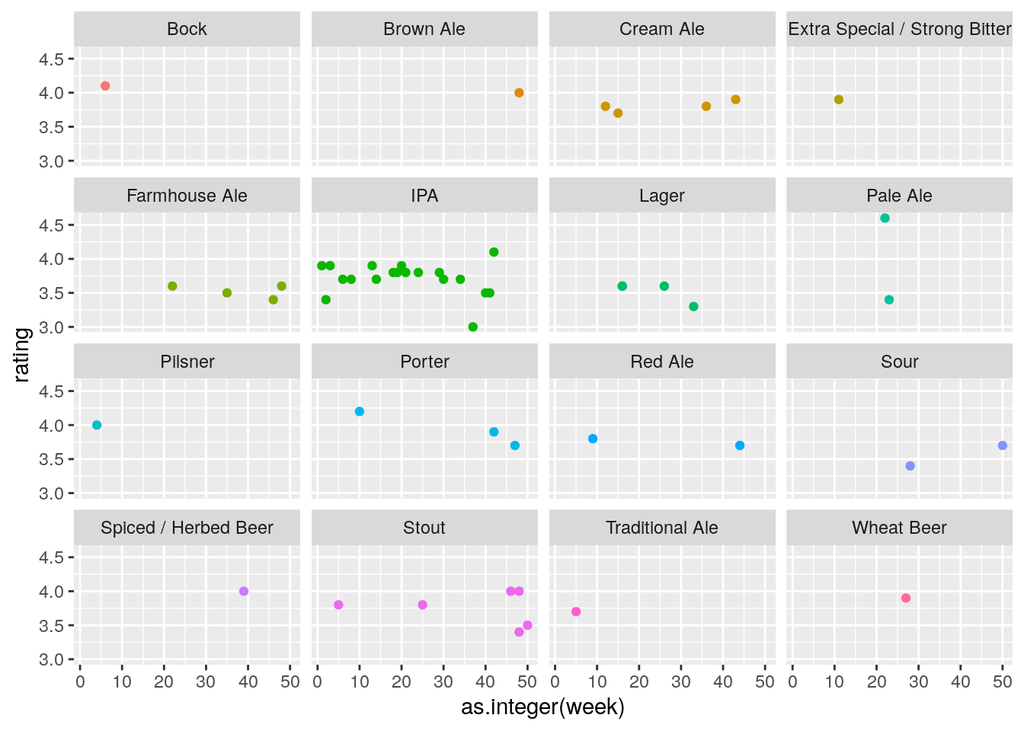

## Getting more hits on Untappd?

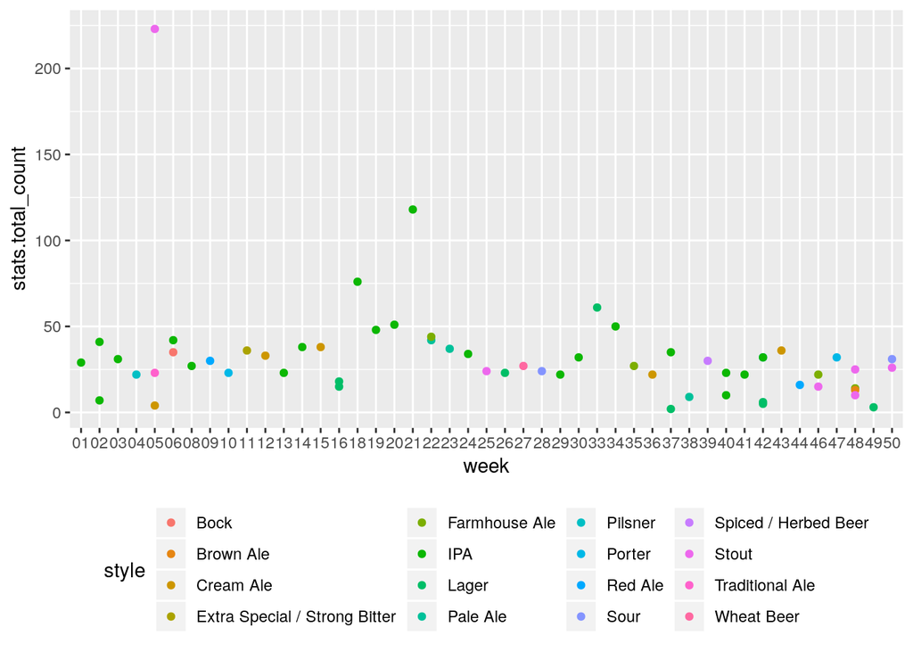

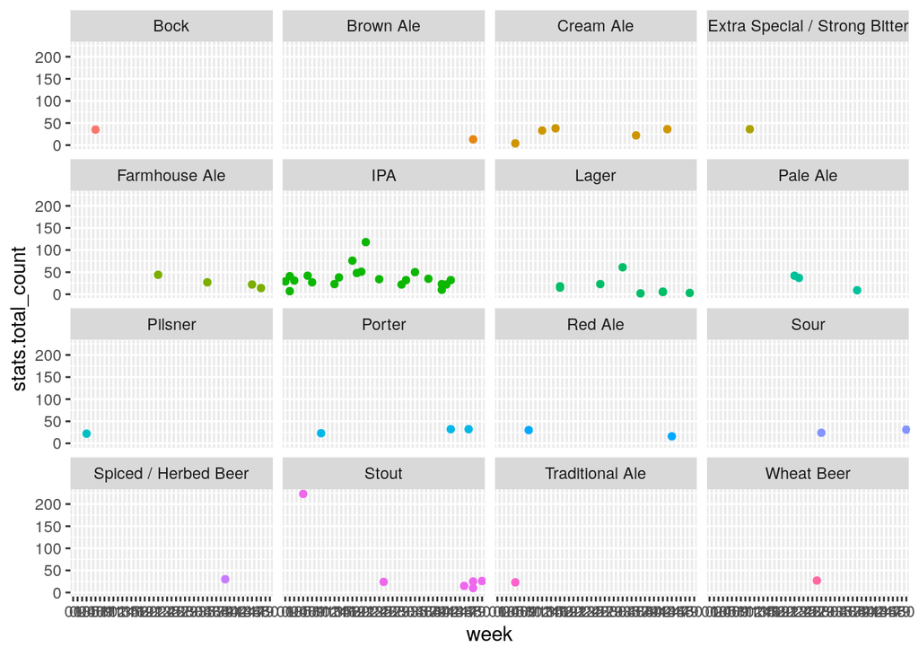